# Illustration of the new DE methods in fastTopics

Peter Carbonetto

2021-07-13

In this short vignette I will illustrate the new differential expression (DE) methods using a small subset of the PBMC single-cell RNA-seq data.

Load fastTopics and a few other packages used in the analysis:

```r
library(Matrix)
library(fastTopics)
library(ggplot2)
library(ggrepel)
library(cowplot)
```

Load the UMI counts for 3,774 cells:

```r
data(pbmc_facs)
dim(pbmc_facs$counts)
# [1]  3774 16791
```

A pre-fitted topic model is provided, so we can quickly move on to the DE analysis:

```r
summary(pbmc_facs$fit)
# Set show.size.factors = TRUE, show.mixprops = TRUE and/or show.topic.reps = TRUE in print(...) to show more informataion
# Model overview:
#   Number of data rows, n: 3774
#   Number of data cols, m: 16791
#   Rank/number of topics, k: 6
# Evaluation of model fit (200 updates performed):
#   Poisson NMF log-likelihood: -8.694952103119e+06
#   Multinomial topic model log-likelihood: -8.677485913674e+06
#   Poisson NMF deviance: +1.084788298921e+07
#   Max KKT residual: +2.042941e-04
```

As a reminder, the topics largely capture the FACS cell-type labeling, with the topic proportions capturing some missed heterogeneity within the FACS populations:

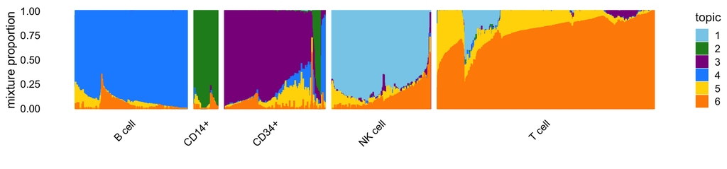

```r
topic_colors <- c("skyblue","forestgreen","darkmagenta","dodgerblue",
                  "gold","darkorange")
structure_plot(pbmc_facs$fit,topics = 1:6,colors = topic_colors,
               grouping = pbmc_facs$samples$subpop,gap = 25)
```

Perform a differential expression analysis, first without the shrinkage step:

```r
set.seed(1)
de1 <- de_analysis(pbmc_facs$fit,pbmc_facs$counts,shrink.method = "none",
                   control = list(nc = 4))
# Using 4 RcppParallel threads.
# Using 4 SOCK threads.
# Progress bar cannot be shown when multithreading is used. For large data sets, the total runtime may be estimated by performing an initial test run with a small number of Monte Carlo samples, e.g., ns = 10; the total runtime should scale roughly linearly in ns, the number of Monte Carlo samples.
# Fitting 16791 Poisson models with k=6 using method="scd".
# Computing log-fold change statistics from 16791 Poisson models with k=6.
```

For reproducible results, we need to set the seed because posteriors of the log-fold change (LFC) statistics are estimated using MCMC. Let’s check the acceptance rates for all combinations of genes and topics:

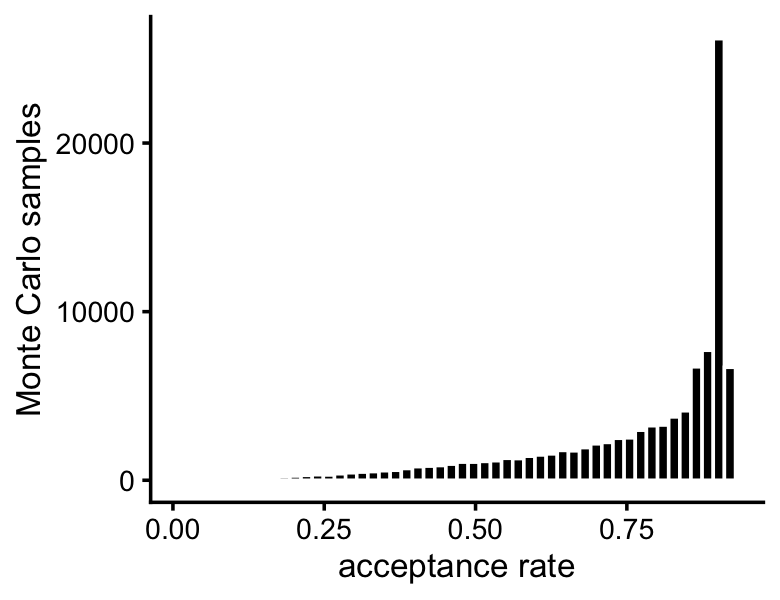

```r
ggplot(data.frame(x = c(de1$ar)),aes(x)) +
  geom_histogram(color = "white",fill = "black",bins = 50) +
  labs(x = "acceptance rate",y = "Monte Carlo samples") +
  theme_cowplot(font_size = 10)
```

Perform a second DE analysis in which we use adaptive shrinkage (ash) to stabilize the LFC estimates:

```r
set.seed(1)
de2 <- de_analysis(pbmc_facs$fit,pbmc_facs$counts,shrink.method = "ash",
                   control = list(nc = 4))
# Using 4 RcppParallel threads.
# Using 4 SOCK threads.
# Progress bar cannot be shown when multithreading is used. For large data sets, the total runtime may be estimated by performing an initial test run with a small number of Monte Carlo samples, e.g., ns = 10; the total runtime should scale roughly linearly in ns, the number of Monte Carlo samples.
# Fitting 16791 Poisson models with k=6 using method="scd".
# Computing log-fold change statistics from 16791 Poisson models with k=6.
# Stabilizing log-fold change estimates using adaptive shrinkage.
```

The adaptive shrinkage does indeed shrink the smallest LFC estimates (with higher levels of uncertainty) toward zero. This plot compares the raw LFC estimates against the stabilized LFC estimates for topic 4:

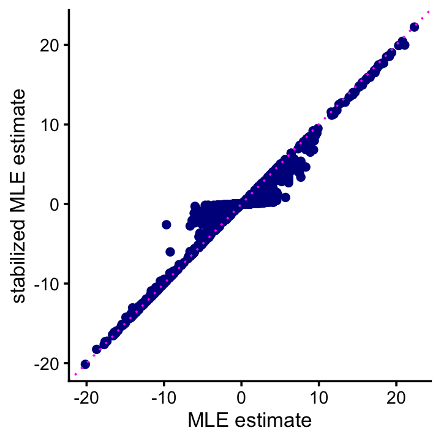

```r
k <- 4
pdat <- data.frame(b1 = de1$est[,k],b2 = de2$est[,k])
ggplot(pdat,aes(x = b1,y = b2)) +
  geom_point(color = "darkblue") +
  geom_abline(intercept = 0,slope = 1,color = "magenta",linetype = "dotted") +
  labs(x = "MLE estimate",y = "stabilized MLE estimate") +
  theme_cowplot(font_size = 10)
```

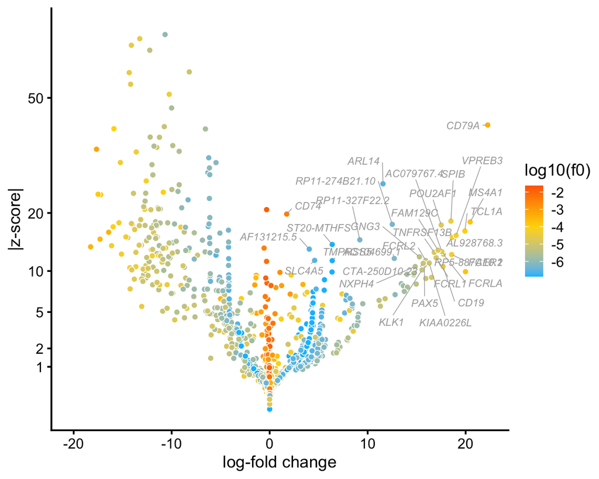

```r
pdat <- data.frame(lfc  = de2$est[,k],
                   z    = abs(de2$z[,k]),
                   f0   = log10(de2$f0),
                   gene = pbmc_facs$genes$symbol,
                   stringsAsFactors = FALSE)
rows <- which(!with(pdat,lfc > 1 & z > 10))
pdat[rows,"gene"] <- ""
ggplot(pdat,aes(x = lfc,y = z,fill = f0,label = gene)) +
  geom_point(color = "white",stroke = 0.3,shape = 21) +
  geom_text_repel(color = "darkgray",size = 2.2,fontface = "italic",
                  segment.color = "darkgray",segment.size = 0.2,
                  min.segment.length = 0,max.overlaps = Inf) +
  scale_y_continuous(trans = "sqrt",limits = c(0,75),
                     breaks = c(0,1,2,5,10,20,50)) +
  scale_fill_gradient2(low = "deepskyblue",mid = "gold",high = "orangered",
                       na.value = "gainsboro",midpoint = -4) +
  labs(x = "log-fold change",y = "|z-score|",fill = "log10(f0)") +
  theme_cowplot(font_size = 10)
```

The top DE genes such as *CD79A*, *CD19* and *MS4A1* point to this topic capturing gene expression in B cells, which aligns well with the FACS labeling.

## Session info

This is the version of R and the packages that were used to generate these results:

```r
sessionInfo()
# R version 3.6.2 (2019-12-12)
# Platform: x86_64-apple-darwin15.6.0 (64-bit)
# Running under: macOS Catalina 10.15.7
#
# Matrix products: default
# BLAS:   /Library/Frameworks/R.framework/Versions/3.6/Resources/lib/libRblas.0.dylib
# LAPACK: /Library/Frameworks/R.framework/Versions/3.6/Resources/lib/libRlapack.dylib
#
# locale:
# [1] en_US.UTF-8/en_US.UTF-8/en_US.UTF-8/C/en_US.UTF-8/en_US.UTF-8
#
# attached base packages:
# [1] stats     graphics  grDevices utils     datasets  methods   base
#
# other attached packages:
# [1] cowplot_1.0.0     ggrepel_0.9.0     ggplot2_3.3.0     fastTopics_0.6-62
# [5] Matrix_1.2-18
#
# loaded via a namespace (and not attached):
#  [1] Rcpp_1.0.7         invgamma_1.1       lattice_0.20-38    tidyr_1.0.0
#  [5] prettyunits_1.1.1  assertthat_0.2.1   zeallot_0.1.0      digest_0.6.23
#  [9] truncnorm_1.0-8    R6_2.4.1           backports_1.1.5    MatrixModels_0.4-1
# [13] evaluate_0.14      coda_0.19-3        httr_1.4.2         pillar_1.4.3
# [17] rlang_0.4.11       progress_1.2.2     lazyeval_0.2.2     data.table_1.12.8
# [21] irlba_2.3.3        SparseM_1.78       rmarkdown_2.3      labeling_0.3
# [25] Rtsne_0.15         stringr_1.4.0      htmlwidgets_1.5.1  munsell_0.5.0
# [29] mixsqp_0.3-46      compiler_3.6.2     xfun_0.11          pkgconfig_2.0.3
# [33] SQUAREM_2017.10-1  mcmc_0.9-6         htmltools_0.4.0    tidyselect_0.2.5
# [37] tibble_2.1.3       quadprog_1.5-8     viridisLite_0.3.0  withr_2.4.2
# [41] crayon_1.3.4       dplyr_0.8.3        MASS_7.3-51.4      grid_3.6.2
# [45] jsonlite_1.6       gtable_0.3.0       lifecycle_0.1.0    magrittr_1.5
# [49] scales_1.1.0       RcppParallel_4.4.2 stringi_1.4.3      farver_2.0.1
# [53] vctrs_0.2.1        tools_3.6.2        glue_1.3.1         purrr_0.3.3
# [57] hms_0.5.2          parallel_3.6.2     yaml_2.2.0         colorspace_1.4-1
# [61] ashr_2.2-51        plotly_4.9.2       knitr_1.26         quantreg_5.54
# [65] MCMCpack_1.4-5
```